# A Bayesian model for habitat and trophic evidence

Author

AJ Smit

Published

August 19, 2026

# Aim

0. None
1. Co-occurrence
2. Use
3. Selection
4. Contribution
5. Dependence

The evidence hierarchy has to be extracted from the literature and the model cannot produce it. That is what FishKelp does. Your model then combines the literature evidence with context information from your questionnaire to produce a posterior distribution of the Habitat Dependency Rank (HDR) and Trophic Dependency Rank (TDR).

Your model estimates continuous HDR and TDR values between zero and one and reports the posterior probability assigned to each evidence level. These probabilities are the more useful result because they keep the meaning of the hierarchy and show the uncertainty around any single classification.

# How I have interpreted the questions

The weighted Beta calculation gives us a prior to work with, but it is not a formal Bayesian rule for combining independent evidence. Averaging alpha and beta values produces a valid Beta distribution; it does not, however, follow from updating with independent observations. I have kept the calculation only as a way of expressing a weak context prior.

The original questions also need some revision before different people can apply them consistently:

1. Geographic, depth and coastal overlap describe *access* to kelp. Some of your original priors let access imply strong use or dependence, which is not justified.
2. The later questions describe the same evidence that informs the likelihood, so using them in both places counts the evidence twice.
3. Several response labels lack numerical thresholds, so two careful extractors can reasonably choose different answers.
4. Your text, tables, examples and plotting code sometimes contain conflicting alpha and beta values.
5. Fixed weights and narrow Beta distributions imply a degree of certainty that we have not yet justified.

I have kept the questions but changed the role of some of them. Habitat Q1-Q3 and Trophic Q1-Q4 provide a weak context prior. The later questions are applied to each literature source and inform the model through the likelihood. This separation prevents us from using the same observation once in the prior and again in the likelihood. The numerical priors from your worked examples remain in `data/zoe_worked_prior_profiles.csv`, so that we do not lose the original work, but they are not used in the analysis below.

The evidence levels are ordered categories, not measured proportions, and the likelihood needs to respect that distinction. I use an ordered-probit likelihood. A record at a given level is most probable when the unknown HDR or TDR lies within the corresponding interval. The knowledge-specificity class controls the observation error, with High-specificity records contributing more precise information than Medium- or Low-specificity records.

The model estimates between-source variation separately for habitat and trophic evidence. Independent records that support the same level concentrate the posterior, whereas disagreement among records increases the estimated variation and widens it. This gives the agreement among studies a direct role in the uncertainty.

This calculation treats records as independent. Duplicate publications, multiple reports from the same samples, or reviews repeating a primary result must be grouped before fitting, otherwise repetition can be mistaken for independent agreement.

The simulated values in `Posteriors.qmd` do not provide such a likelihood. They are drawn from a selected prior and fitted back to that distribution, so no observed evidence updates the prior. The analysis below replaces those values with literature records classified against the evidence hierarchy.

| Questionnaire block | Recommended role in the model |
| --- | --- |
| Habitat and trophic Q1-Q3 | Broad prior information about access to kelp |
| Habitat Q4-Q7 | Literature evidence |
| Trophic Q4 | Broad prior information about feeding mode |
| Trophic Q5-Q7 | Literature evidence |

This division retains the ecological content of the questions while separating background traits from observations of the kelp relationship. I think this is the main change needed before we apply the model to all species.

The revised response definitions are in `data/zoe_prior_response_definitions.csv` and `data/zoe_evidence_response_definitions.csv`. Each person extracting evidence should record the response code, the supporting text or value, and its source. “Not assessed” must remain distinct from evidence of no relationship.

# Set up the analysis

The paths are relative to this file, so the analysis will run from a fresh clone of the repository.

```r
library(ggplot2)

qmd_path <- normalizePath(knitr::current_input(dir = TRUE), mustWork = TRUE)
analysis_dir <- dirname(qmd_path)
repo_root <- dirname(analysis_dir)

source(file.path(repo_root, "R", "zoe_hdr_tdr_model.R"))

prior_path <- file.path(
  repo_root,
  "data",
  "zoe_revised_prior_profile_Pachymetopon_blochii.csv"
)
prior_definitions_path <- file.path(
  repo_root,
  "data",
  "zoe_prior_response_definitions.csv"
)
evidence_definitions_path <- file.path(
  repo_root,
  "data",
  "zoe_evidence_response_definitions.csv"
)
evidence_path <- file.path(
  repo_root,
  "data",
  "fishkelp_v7",
  "fishkelp_model_records_v7.csv"
)
fishkelp_summary_path <- file.path(
  analysis_dir,
  "posterior_outputs",
  "Pachymetopon_blochii_posterior_summary_v7.csv"
)
output_dir <- file.path(analysis_dir, "zoe_posterior_outputs")
dir.create(output_dir, recursive = TRUE, showWarnings = FALSE)

selected_species <- "Pachymetopon blochii"

prior_answers <- read.csv(prior_path, stringsAsFactors = FALSE)
prior_definitions <- read.csv(prior_definitions_path, stringsAsFactors = FALSE)
evidence_definitions <- read.csv(
  evidence_definitions_path,
  stringsAsFactors = FALSE,
  na.strings = c("", "NA")
)
evidence <- read.csv(
  evidence_path,
  stringsAsFactors = FALSE,
  check.names = FALSE
)

# The packaged source retains its original column name in position eight.
# Within this analysis we call it the evidence level.
names(evidence)[8] <- "level"

selected_evidence <- evidence[evidence$species == selected_species, ]
```

# Define the responses

The context responses have target means from 0.05 to 0.20. Access to kelp can make a relationship plausible, but it cannot by itself support use, selection, contribution or dependence. A common concentration of eight converts each target mean to a Beta distribution:

$$\alpha = 8\mu, \qquad \beta = 8(1-\mu).$$

The same rule is used for every option. These values remain expert judgements, and we will need to assess them with prior-predictive checks. Applying one rule does at least make the judgement explicit and avoids unrelated choices of alpha and beta for each response.

```r
knitr::kable(
  prior_answers[, c(
    "route",
    "question",
    "parameter",
    "response_code",
    "selected_option",
    "alpha",
    "beta",
    "weight"
  )],
  digits = 3,
  caption = paste("Revised context-prior responses for", selected_species)
)
```

Revised context-prior responses for Pachymetopon blochii

| route | question | parameter | response_code | selected_option | alpha | beta | weight |
| --- | --- | --- | --- | --- | --- | --- | --- |
| Habitat | Q1 | Geographic overlap | G2 | Partial overlap | 1.2 | 6.8 | 0.333 |
| Habitat | Q2 | Vertical overlap | D2 | Partial overlap | 1.2 | 6.8 | 0.333 |
| Habitat | Q3 | Coastal access | C3 | Extensive access | 1.6 | 6.4 | 0.333 |
| Trophic | Q1 | Geographic overlap | G2 | Partial overlap | 1.2 | 6.8 | 0.200 |
| Trophic | Q2 | Vertical overlap | D2 | Partial overlap | 1.2 | 6.8 | 0.200 |
| Trophic | Q3 | Coastal access | C3 | Extensive access | 1.6 | 6.4 | 0.200 |
| Trophic | Q4 | Feeding guild | F2 | Mixed plant and animal diet | 1.2 | 6.8 | 0.400 |

This remains provisional. You should calculate the geographic and depth percentages from defined range layers before assigning a final classification; the table specifies the required format but does not replace that work.

The evidence definitions apply a cumulative criterion: one paper contributes the highest level supported by its observations for each route. Frequency, dietary proportion and life stage remain useful information, but none raises the evidence level without the observation required by the next level.

# Combine your question priors

I have taken the proposed weights as the centre of a distribution. The concentration parameter controls how much the sampled weights vary around those values: a low concentration permits more variation, whereas a high concentration keeps them close to the proposed weights. I use 25 as a working value and examine the effect of changing it below.

```r
habitat_answers <- prior_answers[prior_answers$route == "Habitat", ]
trophic_answers <- prior_answers[prior_answers$route == "Trophic", ]

habitat_prior <- integrate_question_priors(habitat_answers)
trophic_prior <- integrate_question_priors(trophic_answers)

weight_concentration <- 25
n_weight_draws <- 4000

habitat_prior_draws <- draw_integrated_priors(
  question_answers = habitat_answers,
  weight_concentration = weight_concentration,
  n_draws = n_weight_draws,
  seed = 20260819
)
trophic_prior_draws <- draw_integrated_priors(
  question_answers = trophic_answers,
  weight_concentration = weight_concentration,
  n_draws = n_weight_draws,
  seed = 20260820
)

integrated_priors <- rbind(
  data.frame(route = "Habitat", habitat_prior),
  data.frame(route = "Trophic", trophic_prior)
)

knitr::kable(
  integrated_priors,
  digits = 3,
  caption = "Integrated weak context priors from the revised questionnaire."
)
```

Integrated weak context priors from the revised questionnaire.

| route | alpha | beta | mean | lower_95 | upper_95 |
| --- | --- | --- | --- | --- | --- |
| Habitat | 1.333 | 6.667 | 0.167 | 0.011 | 0.472 |
| Trophic | 1.280 | 6.720 | 0.160 | 0.009 | 0.463 |

```r
uncertain_prior_summary <- rbind(
  summarise_integrated_prior_draws(habitat_prior_draws, "Habitat"),
  summarise_integrated_prior_draws(trophic_prior_draws, "Trophic")
)

knitr::kable(
  uncertain_prior_summary,
  digits = 3,
  caption = "Variation in the prior mean after uncertainty in question weights is included."
)
```

Variation in the prior mean after uncertainty in question weights is included.

| route | mean_rank | lower_95 | upper_95 |
| --- | --- | --- | --- |
| Habitat | 0.167 | 0.158 | 0.177 |
| Trophic | 0.160 | 0.154 | 0.169 |

The habitat calculation gives Beta(1.33333, 6.66667). The trophic calculation gives Beta(1.28, 6.72). These are the central values of the revised priors, around which the model averages over alternative question weights. No FishKelp prior enters this calculation.

# Prepare the literature evidence

Each paper contributes an ordered evidence level and a knowledge-specificity class (i.e., FishKelp). The latter determines the observation standard deviation used in the likelihood.

```r
specificity_sd <- c(
  High = 0.10,
  Medium = 0.20,
  Low = 0.30
)

model_settings <- data.frame(
  specificity = names(specificity_sd),
  observation_sd = unname(specificity_sd)
)

knitr::kable(
  model_settings,
  caption = "Observation uncertainty used for each knowledge-specificity class."
)
```

Observation uncertainty used for each knowledge-specificity class.

| specificity | observation_sd |
| --- | --- |
| High | 0.1 |
| Medium | 0.2 |
| Low | 0.3 |

A smaller standard deviation gives the record more influence on the underlying HDR or TDR. The three values used here are working choices, but they probably need to be checked in a sensitivity analysis and calibrated before publication/used in your thesis.

```r
route_names <- c(H = "Habitat", T = "Trophic")
level_names <- c(
  "None",
  "Co-occurrence",
  "Use",
  "Selection",
  "Contribution",
  "Dependence"
)

evidence_counts <- as.data.frame(
  table(
    route = factor(selected_evidence$route, levels = c("H", "T")),
    level = factor(selected_evidence$level, levels = 0:5)
  )
)
evidence_counts <- evidence_counts[evidence_counts$Freq > 0, ]
evidence_counts$route <- route_names[as.character(evidence_counts$route)]
evidence_counts$level <- paste0(
  as.integer(evidence_counts$level) - 1,
  ": ",
  level_names[as.integer(evidence_counts$level)]
)
names(evidence_counts)[3] <- "records"

knitr::kable(
  evidence_counts,
  caption = paste("Literature evidence for", selected_species)
)
```

Literature evidence for Pachymetopon blochii

| route | level | records |
| --- | --- | --- |
| Habitat | 0: None | 29 |
| Trophic | 0: None | 3 |
| Habitat | 1: Co-occurrence | 8 |
| Trophic | 1: Co-occurrence | 1 |
| Habitat | 2: Use | 2 |
| Trophic | 2: Use | 3 |

# Fit the habitat and trophic models

The model evaluates HDR or TDR and between-source variation on a fine grid, while averaging over uncertainty in the question weights. Numerical integration is adequate for a model of this size, so Stan and Markov chain Monte Carlo are unnecessary here.

```r
habitat_records <- selected_evidence[selected_evidence$route == "H", ]
trophic_records <- selected_evidence[selected_evidence$route == "T", ]

habitat_fit <- fit_evidence_route(
  records = habitat_records,
  prior_draws = habitat_prior_draws,
  specificity_sd = specificity_sd
)

trophic_fit <- fit_evidence_route(
  records = trophic_records,
  prior_draws = trophic_prior_draws,
  specificity_sd = specificity_sd
)

posterior_summary <- rbind(
  summarise_evidence_route(habitat_fit, "Habitat"),
  summarise_evidence_route(trophic_fit, "Trophic")
)

level_probabilities <- rbind(
  calculate_level_probabilities(habitat_fit, "Habitat"),
  calculate_level_probabilities(trophic_fit, "Trophic")
)

write.csv(
  posterior_summary,
  file.path(output_dir, "Pachymetopon_blochii_HDR_TDR_summary.csv"),
  row.names = FALSE
)
write.csv(
  level_probabilities,
  file.path(output_dir, "Pachymetopon_blochii_level_probabilities.csv"),
  row.names = FALSE
)

knitr::kable(
  posterior_summary,
  digits = 3,
  caption = "Posterior HDR and TDR summaries for the worked fish."
)
```

Posterior HDR and TDR summaries for the worked fish.

| route | posterior_mean | posterior_median | lower_95 | upper_95 | expected_level | expected_level_lower_95 | expected_level_upper_95 | source_variation_median | source_variation_lower_95 | source_variation_upper_95 |
| --- | --- | --- | --- | --- | --- | --- | --- | --- | --- | --- |
| Habitat | 0.032 | 0.027 | 0.002 | 0.084 | 0.159 | 0.011 | 0.421 | 0.065 | 0.000 | 0.208 |
| Trophic | 0.138 | 0.132 | 0.015 | 0.304 | 0.692 | 0.076 | 1.520 | 0.133 | 0.003 | 0.378 |

Multiplying the continuous HDR or TDR by five places the posterior on the 0-5 reporting scale while keeping the continuous rank. The source-variation columns describe agreement among records after allowing for knowledge specificity, with values near zero indicating closer agreement.

# Comparison with FishKelp

FishKelp provides a useful comparison, but it is not used to fit this model. The analyses use the same fish and literature records, although their priors and model structures differ. Similar estimates would support the consistency of the two approaches; marked differences would direct us back to the questions, weights and likelihood.

**Because both models pick from the same literature records, this comparison is not an independent validation.** A stronger test would use species withheld during development, new sources, or evidence extracted independently.

```r
fishkelp_summary <- read.csv(
  fishkelp_summary_path,
  stringsAsFactors = FALSE,
  check.names = FALSE
)

zoe_comparison <- posterior_summary[, c(
  "route",
  "expected_level",
  "expected_level_lower_95",
  "expected_level_upper_95"
)]
names(zoe_comparison) <- c(
  "route",
  "mean",
  "lower_95",
  "upper_95"
)
zoe_comparison$model <- "Zoë HDR/TDR"

fishkelp_comparison <- data.frame(
  route = fishkelp_summary$Route,
  mean = fishkelp_summary$Mean,
  lower_95 = fishkelp_summary[["2.5%"]],
  upper_95 = fishkelp_summary[["97.5%"]],
  model = "FishKelp v7"
)

model_comparison <- rbind(zoe_comparison, fishkelp_comparison)
model_comparison <- model_comparison[
  order(model_comparison$route, model_comparison$model),
]

write.csv(
  model_comparison,
  file.path(output_dir, "Pachymetopon_blochii_model_comparison.csv"),
  row.names = FALSE
)

knitr::kable(
  model_comparison,
  digits = 3,
  caption = "Model estimates on the common 0-5 evidence scale."
)
```

Model estimates on the common 0-5 evidence scale.

|  | route | mean | lower_95 | upper_95 | model |
| --- | --- | --- | --- | --- | --- |
| 4 | Habitat | 0.409 | 0.191 | 0.654 | FishKelp v7 |
| 1 | Habitat | 0.159 | 0.011 | 0.421 | Zoë HDR/TDR |
| 3 | Trophic | 0.468 | 0.068 | 1.133 | FishKelp v7 |
| 2 | Trophic | 0.692 | 0.076 | 1.520 | Zoë HDR/TDR |

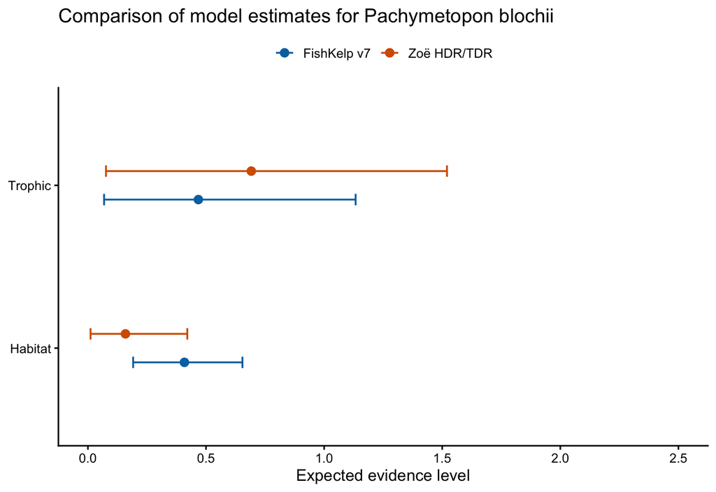

Zoë’s route-specific posterior estimates compared with the FishKelp benchmark.

```r
comparison_plot <- ggplot(
  model_comparison,
  aes(x = mean, y = route, colour = model)
) +
  geom_errorbarh(
    aes(xmin = lower_95, xmax = upper_95),
    height = 0.14,
    position = position_dodge(width = 0.35),
    linewidth = 0.7
  ) +
  geom_point(
    position = position_dodge(width = 0.35),
    size = 2.8
  ) +
  scale_colour_manual(
    values = c("Zoë HDR/TDR" = "#D55E00", "FishKelp v7" = "#0072B2")
  ) +
  scale_x_continuous(limits = c(0, 2.5), breaks = seq(0, 2.5, 0.5)) +
  labs(
    title = paste("Comparison of model estimates for", selected_species),
    x = "Expected evidence level",
    y = NULL,
    colour = NULL
  ) +
  theme_classic(base_size = 13) +
  theme(legend.position = "top")

ggsave(
  file.path(output_dir, "Pachymetopon_blochii_model_comparison.png"),
  comparison_plot,
  width = 8,
  height = 5.5,
  dpi = 300
)
ggsave(
  file.path(output_dir, "Pachymetopon_blochii_model_comparison.pdf"),
  comparison_plot,
  width = 8,
  height = 5.5
)

comparison_plot
```

For Habitat, the two posterior means differ by 0.25 levels. The mean Trophic estimates differ by 0.224 levels. The 95% intervals overlap for both routes, which suggests broad compatibility rather than close agreement. The comparison remains approximate because the two models define their latent quantities differently.

The median between-source variation is 0.065 for Habitat and 0.133 for Trophic. The higher Trophic value follows from the wider spread of trophic records across evidence levels and contributes to the wider posterior.

# Sensitivity to the question weights

The concentration of the Dirichlet distribution gives our confidence in the proposed weights. The values below represent broad, moderate and narrow uncertainty around the same central values. A biological conclusion should not depend on one choice of concentration.

```r
weight_concentrations <- c(10, 25, 100)

fit_weight_sensitivity <- function(
  concentration,
  answers,
  records,
  route,
  seed
) {
  prior_draws <- draw_integrated_priors(
    question_answers = answers,
    weight_concentration = concentration,
    n_draws = 1500,
    seed = seed + concentration
  )
  fit <- fit_evidence_route(
    records = records,
    prior_draws = prior_draws,
    specificity_sd = specificity_sd
  )
  summary <- summarise_evidence_route(fit, route)

  data.frame(
    route = route,
    weight_concentration = concentration,
    expected_level = summary$expected_level,
    lower_95 = summary$expected_level_lower_95,
    upper_95 = summary$expected_level_upper_95
  )
}

habitat_weight_sensitivity <- do.call(
  rbind,
  lapply(
    weight_concentrations,
    fit_weight_sensitivity,
    answers = habitat_answers,
    records = habitat_records,
    route = "Habitat",
    seed = 20261000
  )
)
trophic_weight_sensitivity <- do.call(
  rbind,
  lapply(
    weight_concentrations,
    fit_weight_sensitivity,
    answers = trophic_answers,
    records = trophic_records,
    route = "Trophic",
    seed = 20262000
  )
)

weight_sensitivity <- rbind(
  habitat_weight_sensitivity,
  trophic_weight_sensitivity
)

write.csv(
  weight_sensitivity,
  file.path(output_dir, "Pachymetopon_blochii_weight_sensitivity.csv"),
  row.names = FALSE
)

knitr::kable(
  weight_sensitivity,
  digits = 3,
  caption = "Sensitivity of the expected evidence level to uncertainty in question weights."
)
```

Sensitivity of the expected evidence level to uncertainty in question weights.

| route | weight_concentration | expected_level | lower_95 | upper_95 |
| --- | --- | --- | --- | --- |
| Habitat | 10 | 0.159 | 0.011 | 0.420 |
| Habitat | 25 | 0.159 | 0.011 | 0.421 |
| Habitat | 100 | 0.159 | 0.011 | 0.421 |
| Trophic | 10 | 0.691 | 0.076 | 1.520 |
| Trophic | 25 | 0.692 | 0.077 | 1.520 |
| Trophic | 100 | 0.692 | 0.077 | 1.520 |

The estimates change little across these concentration values because the revised context questions have low and similar target means. The relative question weights do not determine the result for this fish, although they may have more influence when the context answers differ more strongly among questions.

# Posterior distributions

These figures are supposed to be similar to your original posterior plots that you like so much. The dashed blue line shows the integrated prior, the red line shows the posterior after adding the literature evidence, and the pale vertical bands mark the six evidence levels.

```r
plot_posterior <- function(fit, route, rank_name) {
  level_bands <- data.frame(
    xmin = c(0, 0.10, 0.30, 0.50, 0.70, 0.90),
    xmax = c(0.10, 0.30, 0.50, 0.70, 0.90, 1),
    level = factor(0:5)
  )

  plot_data <- rbind(
    data.frame(
      rank = fit$theta,
      density = fit$prior_density,
      distribution = "Prior"
    ),
    data.frame(
      rank = fit$theta,
      density = fit$posterior_density,
      distribution = "Posterior"
    )
  )

  ggplot(plot_data, aes(x = rank, y = density)) +
    geom_rect(
      data = level_bands,
      aes(xmin = xmin, xmax = xmax, ymin = -Inf, ymax = Inf, fill = level),
      inherit.aes = FALSE,
      alpha = 0.08,
      show.legend = FALSE
    ) +
    geom_line(
      aes(colour = distribution, linetype = distribution),
      linewidth = 1.05
    ) +
    scale_colour_manual(values = c(Prior = "#0072B2", Posterior = "#D55E00")) +
    scale_linetype_manual(values = c(Prior = "dashed", Posterior = "solid")) +
    scale_x_continuous(
      limits = c(0, 1),
      breaks = c(0, 0.10, 0.30, 0.50, 0.70, 0.90, 1)
    ) +
    labs(
      title = paste(route, "evidence for", selected_species),
      subtitle = "Zoë's integrated prior updated with ordered literature evidence",
      x = rank_name,
      y = "Density",
      colour = NULL,
      linetype = NULL
    ) +
    theme_classic(base_size = 13) +
    theme(legend.position = "top")
}
```

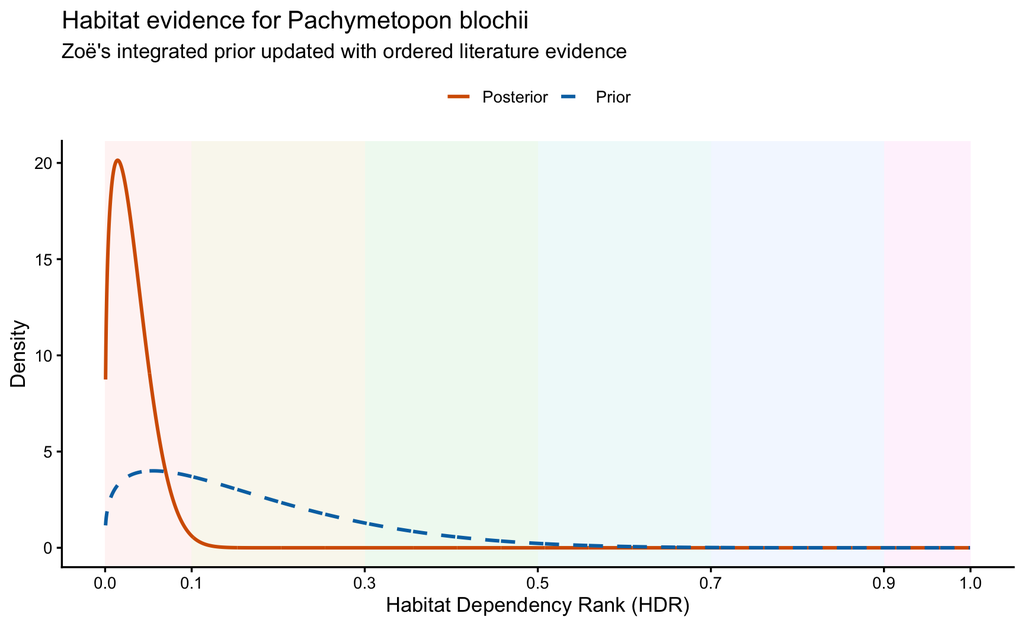

Prior and posterior distribution for the Habitat Dependency Rank.

```r
habitat_plot <- plot_posterior(
  habitat_fit,
  route = "Habitat",
  rank_name = "Habitat Dependency Rank (HDR)"
)

ggsave(
  file.path(output_dir, "Pachymetopon_blochii_HDR_posterior.png"),
  habitat_plot,
  width = 9,
  height = 5.5,
  dpi = 300
)
ggsave(
  file.path(output_dir, "Pachymetopon_blochii_HDR_posterior.pdf"),
  habitat_plot,
  width = 9,
  height = 5.5
)

habitat_plot
```

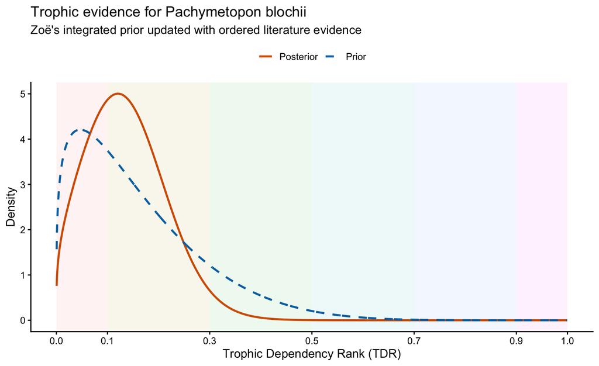

Prior and posterior distribution for the Trophic Dependency Rank.

```r
trophic_plot <- plot_posterior(
  trophic_fit,
  route = "Trophic",
  rank_name = "Trophic Dependency Rank (TDR)"
)

ggsave(
  file.path(output_dir, "Pachymetopon_blochii_TDR_posterior.png"),
  trophic_plot,
  width = 9,
  height = 5.5,
  dpi = 300
)
ggsave(
  file.path(output_dir, "Pachymetopon_blochii_TDR_posterior.pdf"),
  trophic_plot,
  width = 9,
  height = 5.5
)

trophic_plot
```

# Probabilities for the evidence levels

The posterior distributions extend across the boundaries between evidence levels. I would report all six probabilities rather than assign one level and omit the uncertainty around it.

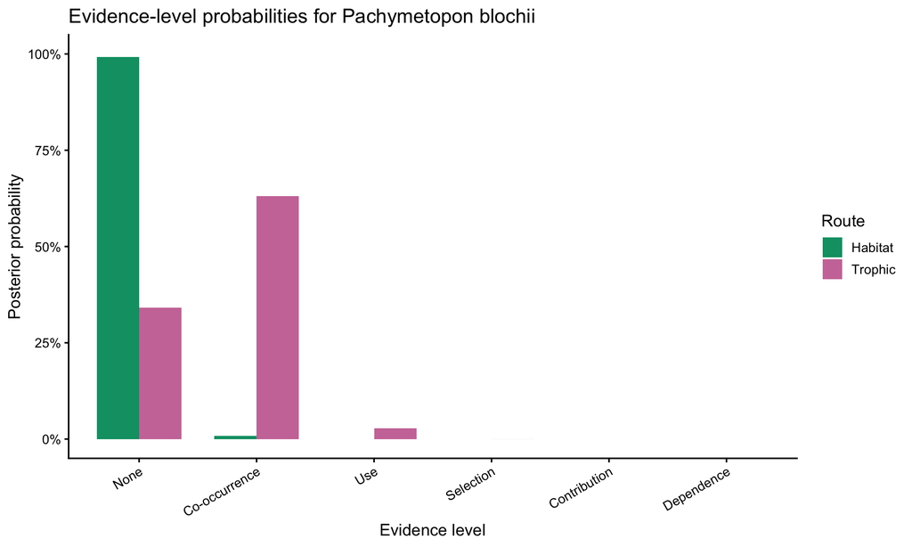

Posterior probability assigned to each evidence level.

```r
level_probabilities$evidence_level <- factor(
  level_probabilities$evidence_level,
  levels = level_names
)

level_plot <- ggplot(
  level_probabilities,
  aes(x = evidence_level, y = posterior_probability, fill = route)
) +
  geom_col(position = "dodge", width = 0.72) +
  scale_fill_manual(values = c(Habitat = "#009E73", Trophic = "#CC79A7")) +
  scale_y_continuous(
    limits = c(0, 1),
    labels = function(value) paste0(round(100 * value), "%")
  ) +
  labs(
    title = paste("Evidence-level probabilities for", selected_species),
    x = "Evidence level",
    y = "Posterior probability",
    fill = "Route"
  ) +
  theme_classic(base_size = 13) +
  theme(axis.text.x = element_text(angle = 30, hjust = 1))

ggsave(
  file.path(output_dir, "Pachymetopon_blochii_level_probabilities.png"),
  level_plot,
  width = 10,
  height = 6,
  dpi = 300
)
ggsave(
  file.path(output_dir, "Pachymetopon_blochii_level_probabilities.pdf"),
  level_plot,
  width = 10,
  height = 6
)

level_plot
```

```r
level_probability_table <- level_probabilities
level_probability_table$posterior_probability <- round(
  100 * level_probability_table$posterior_probability,
  1
)
names(level_probability_table)[4] <- "posterior probability (%)"

knitr::kable(
  level_probability_table,
  caption = "Posterior probabilities for all six evidence levels."
)
```

Posterior probabilities for all six evidence levels.

| route | level | evidence_level | posterior probability (%) |
| --- | --- | --- | --- |
| Habitat | 0 | None | 99.2 |
| Habitat | 1 | Co-occurrence | 0.8 |
| Habitat | 2 | Use | 0.0 |
| Habitat | 3 | Selection | 0.0 |
| Habitat | 4 | Contribution | 0.0 |
| Habitat | 5 | Dependence | 0.0 |
| Trophic | 0 | None | 34.2 |
| Trophic | 1 | Co-occurrence | 63.1 |
| Trophic | 2 | Use | 2.7 |
| Trophic | 3 | Selection | 0.0 |
| Trophic | 4 | Contribution | 0.0 |
| Trophic | 5 | Dependence | 0.0 |

# How to run the full suite of fish

The next step is to prepare the inputs for each fish, while keeping the habitat and trophic assessments separate.

1. Copy `data/zoe_prior_profile_template.csv` for each fish. Use `data/zoe_revised_prior_profile_Pachymetopon_blochii.csv` as the completed reference example.
2. Add the scientific name in the `species` column.
3. Select a response code from `data/zoe_prior_response_definitions.csv`. Copy the corresponding label, alpha and beta rather than entering new values.
4. Record the source, value and short justification used for every context answer. Complete these answers separately from the evidence extraction.
5. Draw plausible integrated priors for each route with `draw_integrated_priors()`.
6. Classify every independent literature source using `data/zoe_evidence_response_definitions.csv` and `data/zoe_evidence_extraction_template.csv`. Record “not assessed” for a route without information. Keep only the highest supported level per independent sample, fish and route, and use `source_cluster_id` to link shared samples.
7. Fit the two routes separately with `fit_evidence_route()`.
8. Save the continuous HDR and TDR summaries, the six level probabilities and both posterior figures.
9. Repeat the analysis with narrower and wider knowledge-specificity standard deviations. Report conclusions that remain stable across those settings.
10. Compare each route’s expected level with the FishKelp benchmark. Investigate large differences; do not tune the model only to force agreement.
11. Ask a second person to classify a concealed pilot set. Compare response codes, highest levels and “not assessed” decisions. Resolve ambiguous definitions before the full extraction and report weighted agreement.

The complete Blamey and Bolton fish list is in `data/fishkelp_v7/blamey_bolton_2018_fish.csv`. The evidence data cover all 30 fish, but the context questions have not yet been completed for every species. We cannot infer those answers from the scientific names alone.

# Flaws in the thinking

I think this version gives us a model that can be tested, but it does not resolve several parts of the underlying logic.

1. The hierarchy describes the strongest type of claim supported by a study. The continuous HDR and TDR summarise the typical evidence across sources; they do not estimate the probability that a fish is biologically dependent on kelp.
2. Many occurrence studies can pull the posterior down even when one well-designed experiment supports contribution. We need to decide whether the target is the typical relationship across contexts or the strongest causal claim supported by the evidence. These are different quantities.
3. More records are available for well-studied species and accessible habitats. The posterior is conditional on the assembled literature and its reporting biases (i.e., samples are non-random).
4. Papers may use the same samples, repeat an earlier assertion, or share a methodological bias. We must identify these links before agreement is allowed to increase precision.
5. A fish recorded away from kelp can weaken a claim of obligate dependence, but it does not invalidate a reliable observation of kelp use elsewhere. Region, life stage and season may need separate estimates.
6. The context means, Beta concentration, level boundaries and specificity errors are starting/working values, but they are not empirically estimated constants. Probably some sentisitivity analysis and calibration is needed before we can report a final classification.

The second point is the largest unresolved modelling choice. I suggest that a later version should report two results: the posterior distribution of typical HDR or TDR, and the probability that each evidential criterion has been met at least once by independent, High-specificity evidence.

# Decisions to settle before publication

The model runs, but these decisions require ecological agreement before we use it for a complete assessment:

1. Test the operational definitions against a hidden set of papers, revising them where the present wording does not resolve a genuine case.
2. Calibrate the target means and common Beta concentration through structured expert interviews, prior-predictive checks and held-out species.
3. Agree on the boundaries between the six evidence levels. The present analysis uses 0.10, 0.30, 0.50, 0.70 and 0.90 as working boundaries. At the moment these are quite arbitrary.
4. Calibrate the High, Medium and Low observation standard deviations through prior-predictive checks and sensitivity analysis.
5. Examine several Dirichlet concentration values for question-weight uncertainty. Retain the uncertainty in the final reported posteriors.
6. Identify records that share data or repeat the same primary observation. Count each independent line of evidence once, or model the shared source.
7. Set and report an extractor-agreement threshold before the complete run. Preserve disagreements and their resolutions in an audit table.

This gives you a reproducible version of your idea that we can now examine and revise. I would not yet present the numerical results as final species classifications, but I think we are almost there. The next step is to apply the model to all species, while keeping the context and evidence extraction separate and reproducible.